# The influence of objective and subjective social status on meritocracy perception in Chile

Julio Iturra [^1]

# 1 Introduction

Through the satiric novel, *The rise of meritocracy*, Michael Young (1961) introduced the term *meritocracy*, described as a system in which merit, understood as the combination of effort and talent, is the primary distributive mechanism (Sen, 2000). From a sociological standpoint, the meritocratic ideal denotes a social regime in which social inequality is tolerated, and the belief that some deserve to be at a disadvantage is morally justified (Castillo, 2011; Svallfors, 2006).

In recent years the discussion about the rise of economic inequality (Piketty & Goldhammer, 2014) and stagnation of the social mobility rate (OECD, 2018) increased the attention of social scientists on how societies perceive meritocracy due to its relevance in the moral justification of economic inequality (Mijs & Savage, 2020; Roex et al., 2018). It has been shown that the perception of how economic resources are distributed in society tends to be stratified by social status (Aalberg, 2003; Janmaat, 2013). Thus, in societies with a strong attachment to meritocratic ideals, status attainment is mainly attributed to the individual agency rather than structural constraints (Bucca, 2016).

Kluegel & Smith (1986) argues that studying social inequality from a subjective standpoint takes into account elements of individual experience but also allows us to unveil the character of a society’s normative structure. In this regard, evidence suggests that preferences and perceptions are explained, on the one hand, by the hierarchical position in the social structure (Bénabou & Tirole, 2006; Meltzer & Richard, 1981), as well by the perceived social standing (Andersson, 2018b; Castillo et al., 2013; MacClure et al., 2019).

The literature has strongly suggested that socioeconomic status is crucial in explaining general perceptions of inequality (Evans & Kelley, 2017; Manstead, 2018) and meritocracy in particular (Duru-Bellat & Tenret, 2012; Kunovich & Slomczynski, 2007; M. Smith & Matějů, 2012; Xian & Reynolds, 2017). However, the evidence is inconclusive due to discrepancies in the measurement strategy of meritocracy-related constructs, omitting substantive distinctions between perceptions and preferences (Castillo et al., 2021). Furthermore, research in this field has paid more attention to socioeconomic factors for explaining perceived meritocracy, to the detriment of the role of subjective social status and reference groups as an explanatory phenomenon of perceived meritocracy (Evans & Kelley, 2004, 2017).

This article scrutinizes the relationship between objective and subjective social status with perceived meritocracy. In this line, some studies argue that subjective social status can be a proxy for objective status (Andersson, 2018b; Chen & Williams, 2018; Lindemann & Saar, 2014). Nevertheless, it has been shown that the bias on subjective status is influenced by the attributes of reference groups (Evans & Kelley, 2004; Evans et al., 1992). Concerning this evidence, this study aims to understand how meritocracy perception is influenced by socioeconomic factors and subjective social status, in addition to examining the moderating role of the latter.

## 1.1 Meritocracy perception

First, *merit* is understood as the combination of an individual’s effort and ability (Sen, 2000). Second, the meritocratic ideal assumes that status achievement is not constrained by how opportunities are structured in society (McCall et al., 2017). Both constitute the substantive core of how meritocracy can be understood. Nevertheless, studies have paid little attention to the construct measurement of concepts related to meritocracy, and low empirical precision is often noticed due to the indistinctly use of descriptive and normative dimensions (Castillo et al., 2019).

For instance, studies on meritocracy have made undifferentiated use of concepts such as *Meritocratic Beliefs* (Bernardo, 2021; Ellis, 2017; Kunovich & Slomczynski, 2007; McCoy & Major, 2007; Mijs & Hoy, 2021), *Meritocratic Ideals*, (Reynolds & Xian, 2014) or *Perceived Meritocracy* (Xian & Reynolds, 2017), which constitutes a difficulty to empirically assess the role of social status on the perception of meritocracy. This lack of distinction in the literature suggests considering a more accurate definition of the construct. Furthermore, this would lead to more precise about the phenomenon being examined and produce better evidence regarding the empirical study of the subjective aspects of meritocracy (Castillo et al., 2019).

On the one hand, Aalberg (2003) defines *perception* as the subjective estimation of an external object depicted by individuals. Therefore, the descriptive dimension does not consider the normative evaluation of the object. On the other hand, Druckman & Lupia (2016) defines the normative dimension as the expression of preferences, understood as evaluating an external object based on the available information. In addition, Feldman & Steenbergen (2001) suggests that preferences are also influenced by the structure and internalisation of ideological values, which operate as an essential explanatory mechanism (Kulin & Svallfors, 2013). In this context, the descriptive dimension is addressed when we talk about meritocracy perception. In other words, this means “how meritocracy is” rather than “how it should be”. For instance, Garcia (2001) argues that meritocracy perception corresponds to the degree to which individuals consider that their society complies with the principles of a meritocracy, i.e., it functions as a system that allocates rewards based on effort and talent.

## 1.2 Status and meritocracy perception

The evidence on the relationship between social status and meritocracy follows the general assumption that individuals with higher social status have a higher meritocracy perception. From a self-interest approach (Meltzer & Richard, 1981) it is possible to argue that individuals who belong to the higher strata of the income distribution have a favourable perception of meritocracy to the extent that they have accumulated economic resources as a result of their effort and talent. In this line, empirical evidence suggests that higher status positions are related to lower inequality perception (Evans & Kelley, 2017; Kuhn, 2013; Landerretche & Lillo, 2011) and the highest justification of economic inequality (Castillo, 2011; Jasso, 2015; Trump, 2017). Regarding meritocracy, the core idea is that merit explains status achievement. In this sense, if higher perceived equity is related to structural opportunities to get ahead, it is reasonable to argue that meritocracy constitutes the central mechanism for justifying differences in social status (Davey et al., 1999; McCoy & Major, 2007).

Evidence suggests a positive relationship between income and perceptions of meritocracy regarding the importance of individual merit in getting ahead in life (Reynolds & Xian, 2014; Sandoval, 2017; Xian & Reynolds, 2017), as well with the agreement levels regarding how intelligence and skills are rewarded (Castillo et al., 2019; Duru-Bellat & Tenret, 2012). Additionally, it has been shown that lower-income strata decrease the probability of agreeing with the importance of meritocracy, while for the upper strata, the probability is significantly higher (Newman et al., 2015; Solt et al., 2016). The rational self-interest hypothesis assumes that individuals with more economic resources attribute more importance to merit and therefore perceive that they are appropriately rewarded. That said, it is possible to argue that:

> $H_{\text{1a}}$: A higher position in the income distribution is positively associated with perceived meritocracy.

In the same way that income reflects an individual’s economic resources, the study of meritocracy concerning educational attainment has been mainly addressed by studies on social stratification (Goldthorpe, 2003). Studies on meritocracy perception have discussed two theoretical approaches. On the one hand, the *reproductionist* approach (Bernstein, 2003; Bourdieu & Passeron, 2009) supports the *socialisation* hypothesis. The main argument is that school socialisation operates as a normative reinforcement of meritocratic ideals, then educated individuals tend to attribute more importance to merit and justify economic inequality (Duru-Bellat & Tenret, 2012; Lampert, 2013). On the other hand, the *instruction* hypothesis suggests that adherence to meritocratic ideals tends to weaken in individuals with higher educational attainment because they would be more aware of the relationship between individual and structural factors that explain status acquisition (Duru-Bellat & Tenret, 2012; Schneider & Castillo, 2015).

Empirical evidence provides support for both approaches. However, it should be noted that these results can be attributed to differences in the measurement of perceived meritocracy. On the one hand, studies report evidence in favour of the socialisation hypothesis have pointed out that greater educational attainment is associated with greater attributed importance of individual factors in getting ahead in life (Mijs, 2021; Newman et al., 2015; Reynolds & Xian, 2014; Solt et al., 2016; Xian & Reynolds, 2017), as well as determining the attainment of a better salary (Kunovich & Slomczynski, 2007). On the other hand, evidence in favour of the instruction hypothesis shows that individuals with higher educational attainment strongly disagree that people are rewarded for their effort and talent (Bubak, 2019; Castillo et al., 2019; Duru-Bellat & Tenret, 2012). Additionally, the argument of the instructional hypothesis can be complemented by the fact that individuals with greater awareness of inequality may experience feelings of injustice and relative deprivation since individuals with the same educational attainment have access to unequal rewards (Adams, 1965; H. J. Smith et al., 2020). In this sense, it has been shown that individuals with higher educational attainment are those who perceive greater wage inequality (Castillo, 2012). If perceived meritocracy is understood as ” the perception society is based on the principles of meritocracy” (Garcia, 2001), it corresponds to the descriptive appraisals of the link between merit and rewards. Then, we can argue that:

> $H_{\text{1b}}$: Higher educational attainment is negatively associated with perceived meritocracy.

The relationship between social status and meritocracy has focused on income and educational attainment, setting social class aside from the discussion. However, it has been shown that occupation represents a characteristic that synthesises educational attainment and income level (Ganzeboom et al., 1992, 1991), therefore is considered one of the main status symbols in contemporary societies (Chan & Goldthorpe, 2004, 2007). Furthermore, studies on social mobility have shown the relevance of studying social inequality through class schemes because they classify individuals according to their occupation, autonomy and authority in the workspace (Erikson & Goldthorpe, 1992; Erikson & Goldthorpe, 2002).

Evidence on social stratification suggests that occupation-based class schemes assume that individuals are similar in terms of their structural position in the labour market and levels of authority and control over work (Connelly et al., 2016). In this regard, Chan & Goldthorpe (2004) argue that common characteristics do not preclude the possibility of heterogeneity within classes, for instance, in terms of substantive differences in cultural consumption and political preferences (Chan & Goldthorpe, 2007).

Regarding distributive preferences, Svallfors (2006) has suggested that social class, unlike other approaches, reflects individuals’ views of the labour market, mainly how economic resources are distributed. Similarly, Kulin & Svallfors (2013) argue that lower classes have greater exposure to labour market risks, such as the likelihood of job loss and lower wages, meaning that individuals who experience the highest material deprivation and risk exposure would be those with favourable preferences towards redistribution (Rehm, 2009). That said, the main prediction of this literature is that individuals belonging to social classes with higher material well-being would mostly disagree with decreasing economic inequality through redistributive measures.

The study of subjective meritocracy has shown little evidence of the role of social class. For example, M. Smith & Matějů (2012) found that individuals belonging to the emerging petty bourgeoisie show higher levels of agreement with meritocracy than wage earners. These results align with the findings of Sandoval (2017), where skilled and service workers, compared to unskilled workers, attribute greater importance to merit to get ahead in life. On the other hand, Canales (2015) studied the relationship between social mobility and perception of meritocracy in Chile, showing that those who experienced upward social mobility towards the service class are less likely to consider that merit is rewarded in Chile.

In Chile, social mobility studies have analysed changes in the social structure that have shown fluidity in upward social mobility (Torche, 2005). However, it has been shown that these transformations in the occupational structure have not been accompanied by significant changes in disposable income, because the relative income distribution has remained stable over time (Espinoza & Núñez, 2014). Additionally, during the last decade, the size of the “middle classes” has persistently increased, mainly due to the relative increment of professional and technical occupations during the changes in the Chilean social structure known as *mesocratisation* (Mac-Clure et al., 2014). In this sense, it has been shown that these changes were generated by the expansion of tertiary education, accompanied by labour market transformations that resulted in an average wage increase without significantly modifying market income inequality. Using a cohort analysis, Mac-Clure (2012) analysed changes in income of the self-employed class using data from the Socioeconomic Characterisation Survey (CASEN) from 1998 to 2009, focusing on the cohort that joined the labour market from 1990 onwards. The results show the positive impact on wages of having completed higher education, particularly when considering the disparities concerning the quality and prestige of tertiary education institutions, even considering the importance of class origin in the stratified access to higher education (Mac-Clure, 2012).

It can be argued that in contexts of high economic inequality, relative position in occupational terms and upward social mobility bring with them that individuals in such positions are dissatisfied with the idea that efforts are rewarded in their society. In Chile, a sense of frustration has been narrated by individuals with a lower-class background who have experienced upward social mobility (Barozet & Fierro, 2014), pointing out that class background is a constant source of discrimination in the labour market (Cea, 2020). Chile is a country where the middle classes have grown significantly via upward social mobility. It has been shown that meritocratic perception becomes critical regarding meritocracy, mainly among individuals with higher educational attainment and those who work in white-collar occupations. As a result, we can argue that:

> $H_{\text{1c}}$: Working in non-manual and services occupations is negatively associated with perceived meritocracy.

## 1.3 Subjective social status and meritocracy perception

On the one hand, the literature on subjective meritocracy has paid more attention to the structural position of individuals as an explanatory factor for perceptions of meritocracy (Duru-Bellat & Tenret, 2012; Kunovich & Slomczynski, 2007; Reynolds & Xian, 2014). On the other hand, interactions between individuals and groups establish a standpoint that frames experiences regarding social inequality, allowing individuals to generate explanations based on the character of these experiences (García-Castro et al., 2020; Madeira et al., 2019).

Social interactions serve as anchors through which individuals rationalise their social status. It is influenced by normative appraisals of qualitative or ascribed status characteristics such as gender or quantitative such as income or educational level (Jasso, 2001). The empirical study of this phenomenon has been conceptualised as subjective social status, understood as the perception of an individual or group’s social standing in the social hierarchy in comparison to a reference group, such as society itself (Evans & Kelley, 2004; Słomczyński & Kacprowicz, 1986) or to their local communities or social classes (Condon & Wichowsky, 2020). Measuring subjective social status is commonly done using the MacArthur Scale of Subjective Social Status, in which individuals report social status on a 10-rung ladder that aims to represent the different strata of the social hierarchy (Adler et al., 2000).

One of the main findings in this literature is that individuals’ perception of their position in the social hierarchy shows a persistent bias toward the middle of the hierarchy, demonstrating that high-status individuals tend to underestimate their position, while low-status individuals tend to overestimate it (Andersson, 2018a; Chen & Fan, 2015; Lindemann & Saar, 2014; Sudo, 2019). In addition, previous theoretical approaches have suggested that individuals are likely to compare themselves with people or groups perceived as similar. These reference groups contribute to diminishing cognitive dissonance and seek to assemble better estimations about their position in society (Festinger, 1954; Merton & Rossi, 1968).

The literature has suggested that perceptual biases can be explained through an availability heuristic, which reduces cognitive dissonance in situations with limited information (Castillo et al., 2013; Evans & Kelley, 2004). In this line, the characteristics of the closest reference groups shape subjective estimates of social standing, in which the images created about society are influenced by the homophily of their close networks (Evans & Kelley, 2017; Evans et al., 1992). For instance, the Son et al. (2021) study reveals that being a member of an organisation or practising a hobby contributes as symbolic pieces of information that shape the observer’s cognitive patterns of homophily. In other words, people consider that individuals that share these attributes tend to be tied (e.g. friendship) and considered members of a similar group. In this regard, Kim & Lee (2021) have shown that individuals with close networks that concentrate people with high-status occupations tend to report higher subjective social status in Chinese society, where social capital is considered essential. On the other hand, in an individualised society like Japan, the socioeconomic diversity of the close network does not influence subjective social status.

There is substantial evidence that socioeconomic status is a robust predictor of subjective social status, but it has been demonstrated that income, compared to education and class, has a stronger association with the perception of individuals about their standing in society (Andersson, 2018a; Castillo et al., 2013; Iturra & Mellado, 2018). Nevertheless, the literature has shown little evidence about the influence of subjective status on perceptions or preferences towards inequality. For example, Vargas-Salfate et al. (2018) found that higher subjective status is related to a positive perception of the distributive system. Similarly, Schneider & Castillo (2015) found that higher subjective status is related to the highest justification of inequality and higher internal and lower external poverty attributions. In addition, Castillo et al. (2018) found that higher subjective status is related to lower perceptions of inequality, and in turn, to higher perceptions of meritocracy. Based on this evidence, our main prediction is:

> $H_{\text{2}}$: A higher individual subjective social status is positively associated with perceived meritocracy

## 1.4 Status interplay and perceived meritocracy

Subjective social status has been little studied as a phenomenon that could moderate the influence of the direct experiences provided by the material factors (Evans & Kelley, 2017) over perceptions related to economic inequality.

Studies on subjective social status have shown that among higher income groups, the inconsistencies regarding perceived status tend to be higher (Castillo et al., 2013). For instance, Andersson (2018a) has shown that disposable income, years of education and occupational prestige have a positive but non-linear relationship with subjective social status, indicating that individuals on the top rungs of the social hierarchy are those who also manifest the highest levels of variation in subjective status. On the one hand, attention to the role of status inconsistencies on individual preferences has focused on inconsistencies between income level and educational attainment (Kreckel, 1993), demonstrating that a lower correlation between them can explain political preferences (Lenski, 1967; Varas & Contreras, 2015). On the other hand, studies like Sosnaud et al. (2013) have analysed the inconsistencies between class identity and social class as an explanatory phenomenon of political preferences using data from the United States, establishing that those who tend to overestimate their class position prefer to vote for the conservatives; however, these results are not robust to the incorporation of socio-demographic controls.

The literature that considered the role of subjective social status as a moderating variable has mainly focused on how it relates to other subjective variables, paying less attention to how the perception of social status interacts with objective factors like income or education. A study conducted by Fatke (2018) using data from the International Social Survey Programme (ISSP) analysed the role of diagrammatic perceptions of inequality in redistributive preferences and perceptions of meritocracy, focusing on the role of subjective status as a moderator of inequality perception. First, the results show that higher perceptions of inequality lead to higher preferences for redistribution and lower perceptions of meritocracy. Secondly, the relationship between inequality and meritocracy perception becomes weaker for those who perceive themselves as having a higher societal position. On the other hand, a study on European countries (Bobzien, 2019) showed that economic inequality does not influence preferences for redistribution when controlled by perceived inequality because it negatively influences preferences for redistribution and is positively moderated by subjective status. In other words, when the subjective status is higher, the negative relationship of inequality perception with redistributive preferences tends to weaken. Another study by Bernardo (2021) analysed the relationship between intolerance of inequality and perceived meritocracy in a sample of Filipino university students of high subjective social status, indicating that those who perceive themselves to have a higher subjective social status and perceive greater meritocracy tend to justify higher levels of economic inequality.

Experimental studies that have analysed the role of status incongruence have pointed out that it is possible to manipulate individuals’ perceptions about their standing in the social structure. Second, manipulation via informational correction of this bias contributes to a change in attitudes towards inequality. For instance, Cruces et al. (2013) demonstrates that Argentinians from the lowest and highest income decile display the highest levels of bias because those in the lowest stratum tend to overestimate their position in income distribution. In contrast, the wealthiest decile tends to underestimate their standing. Additionally, the experimental manipulation generates that those who have overestimated their relative position and perceived that they were relatively more affluent than they were, tend to demand more redistribution. Similar results are reported by Karadja et al. (2017) in Sweden, observing that older people, educated and cognitively more skilled, tend to be more accurate about their position in the income distribution. In this regard, it is hypothesised that those with stronger meritocratic beliefs (e.g. effort is the cause of wealth) would not be affected by the informational intervention and, therefore, would have fewer preferences toward redistribution. Finally, Hvidberg et al. (2020) have argued that the attributes of the reference groups to which the comparison is engaged, have an effect on the perception of distributive justice, distinguishing between “large groups”, such as people of the same gender or with workers in the same economic sector, and “small groups” (e.g. colleagues or neighbours). In this respect, misperception tends to be higher in large reference groups than in small reference groups. In other words, those who overestimate their position around the median of any reference groups increase their perception of inequality and injustice when informed of their actual position, mainly those belonging to the lowest income stratum.

Studies in Chile have argued that three elements interact in the formation of the perception of social status: socioeconomic status, economic, symbolic and social *capitals*, and moral perceptions about individual achievement (MacClure et al., 2020). In this line, MacClure et al. (2019) have shown that those who identify as lower status tend to have low incomes, less educational attainment, and live in disadvantaged urban areas. However, there are circumstances that individuals identify themselves as low status while belonging to an intermediate or high socioeconomic stratum. On the one hand, it is argued that living in a more traditional neighbourhood or having higher educational credentials can explain this bias regarding the symbolic value of these qualities that represent higher levels of social and cultural capital (MacClure et al., 2019, p. 18). On the other hand, those who identify as high status tend to be consistent concerning their socioeconomic characteristics compared to those who identify with the lower stratum, where educational meritocracy represents a distinguishing criterion of their social position (MacClure et al., 2019, p. 19).

On the one hand, empirical evidence suggests that subjective social status reflects part of the experience of individuals given their position in the social structure. In other words, differences in the perception of social status within socioeconomic strata are expected to influence the perception of meritocracy in society. Therefore, it is possible to argue that:

> $H_{\text{3}}$: the relationship between objective position and perceived meritocracy is positively moderated by subjective social status.

Figure 1.1 depicts the theoretical model proposed for the main hypothesis.

[figure not shown]

Figure 1.1: Theoretical model

# 2 Data, variables and methods

*Data*

Los datos empleados corresponden a la tercera ola del Estudio Longitudinal Social de Chile (COES, 2018), encuesta desarrollada para analizar intertemporalmente la evolucion del conflicto y cohesión social en la sociedad chilena. El muestreo es de carácter probabilístico, estratificado, por conglomerados y multietápico, con un total de 3748 participantes con edad entre 18 y 75 años. Para los análisis se obtuvo una muestra análitica de 2077 casos con información completa.

*Variables*

Las variables del estudio y su descripción pueden observarse en la Tabla 2.1. La variable dependiente principal es la *perceived meritocracy*, operacionalizada a través del promedio de dos indicadores ($\alpha$ = 0.83) que capturan el grado de acuerdo respecto a si en Chile el esfuerzo y inteligencia son recompensados y que han sido empleados en estudios comparados (Duru-Bellat & Tenret, 2012). Ambos indicadores son escalas Likert de cinco categorías, en donde valores más altos representan mayor percepción de meritocracia.

La posición objetiva es medida a través de tres variables. El *Household Income Decile* fue calculado empleando el ingreso mensual percápita del hogar y posteriormente categorizado en deciles. El *Educational level* corresponde a la recodificación del logro educacional en cinco niveles correspondientes a la International Standard Classification of Education (UNESCO, 2012). Finaly, we use a adapted five-category version of the EGP class scheme (Connelly et al., 2016), a common used measurement used in social stratification research (Solís et al., 2019). For the computation of the class scheme we use the Stata package `isko` (Hendrickx, 2002).

The subjective social position is meassured by a 11-point scale variable in which respondents identify themselves in the social ladder by answering *“In our society, some groups are usually at the higher levels, and others tend to be placed at the lower levels of society. Using the presented scale, where 0 is the lowest level and 10 the highest level, where would you put yourself in Chilean society?.”*, were higher values represent a greater perceived social status.

Control variables are age, gender, political identification and the perceived salary gap.

Table 2.1: Study variables

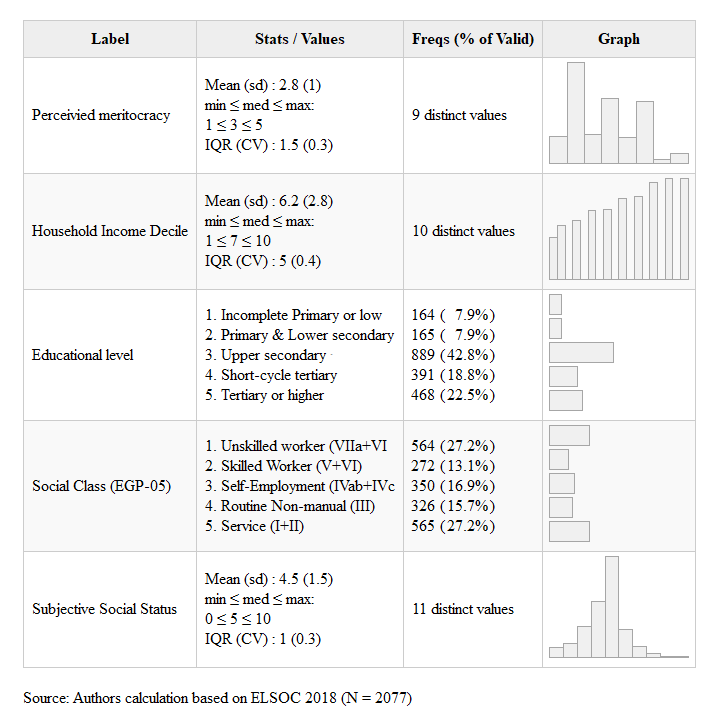

*Method*

Because the dependent variable is a continuous indicator, stepwise ordinary least square regression models are used. First, models are estimated for each of the independent variables. Second, a series of models are estimated that consider the interaction term between objective position and subjective status. The interactions are represented using average marginal effects and linear predictions.

# 3 Results

## 3.1 Descriptive

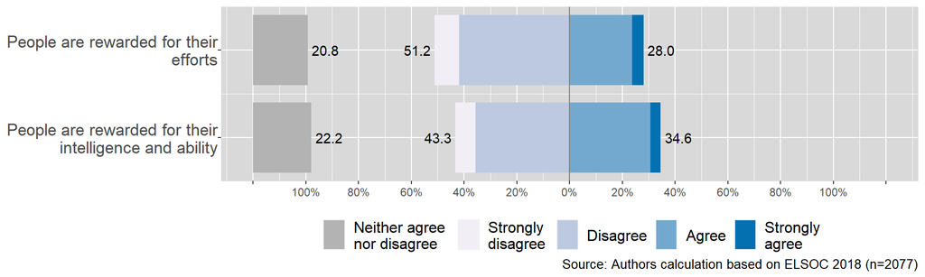

Figure 3.1: Perceived meritocracy items

Figure 3.1 depicts the distribution of responses of the two indicators for the perception of meritocracy, showing that most individuals tend to disagree or strongly disagree with the statement. For example, regarding the statement about how *effort* is rewarded, 51.2% answered that they disagree or strongly disagree. In the same direction, the perception regarding rewards from *intelligence and hability*, the level of disagreement decreases to 43.3%. Finally, about 20% of the respondents do not have a negative or positive perception of the link between rewards and merit in society.

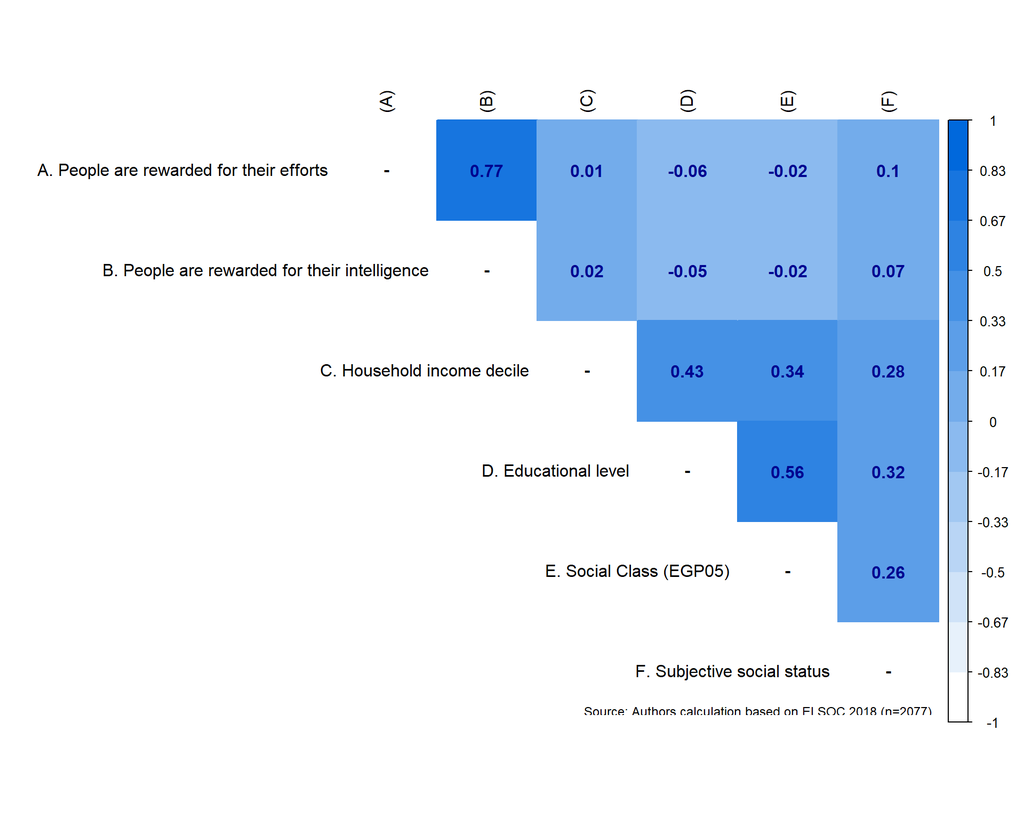

Figure 3.2: Correlation matrix between social status and perceived meritocracy

Figure 3.2 shows the correlations between perceived meritocracy and social status indicators. First, it is observed that the indicators of perceived meritocracy show a strong and positive association (*r* = 0.77) and can be interpreted as evidence in favour of the idea of a common concept. Second, according to the hypothesis, the association between perceived meritocracy and income decile is weak and positive. On the other hand, educational level and social class display a weak and negative association. Third, the association between perceived meritocracy and subjective social status is weak and positive but higher than objective status measures. In this respect, the association between subjective status is slightly stronger with the indicator for *effort* (*r* = 0.1) in contrast to the indicator for *intelligence* (*r* = 0.07).